# Case study: How can a wellness company play it smart?

Osman Mendoza Rosales

5/24/2022

[figure not shown]

BellaBeat

*Introduction.*

*This is a Capstone Project for Google Data Analytics Professional Certification.*

Bellabeat is a high-tech company that manufactures health-focused smart products. The company empowers women with knowledge about their own health and habits.

Since it was founded in 2013, Bellabeat has grown rapidly and quickly positioned itself as a tech-driven wellness company for women. One of the company founders wants to analyze smart device usage data in order to gain insight into how consumers use non-Bellabeat smart devices.

I will focus on another similar company, Fitbit’s, and analyze its smart device data to gain insight into how consumers are using their smart devices.

The insights might help Bellabeat to know about trends in the use of smart devices and, help the marketing department to prepare new strategies which might end in new growth opportunities for the company.

I will use the 6 phases of the analysis process (Ask, Prepare, Process, Analyze, Share and Act) to fulfill the analysis.

# **Phase 1: Ask.**

#### 1. **Identify the business task:**

- Analyze smart devices usage data.
- Provide high-level recommendations for Bellabeat´s marketing strategy.

**Question to guide analysis.**

- ¿How Fitbit´s consumers are using their smart devices?
- ¿What the trends are in the use of the smart devices of Fitbit.?
- ¿How the insights can help marketing department of Bellabeat?

#### 2. **Consider key stakeholders.**

**Primary stakeholders:**

- Urška Sršen: Bellabeat’s cofounder and Chief Creative Officer.
- Sando Mur: Mathematician and Bellabeat’s cofounder; key member of the Bellabeat executive team.

**Secondary Stakeholders:**

- Bellabeat marketing analytics team.

#### 3. **Deliverable.**

To analyze Fitbit smart devices usage and, to find trends which will provide insights that shall be used as marketing strategy for Bellabeat.

# **Phases 2: Prepare.**

**1. Identify the data source:**

**Dataset:** The data set for this exercise is provided by [FitBit Fitness Tracker Data](https://www.kaggle.com/datasets/arashnic/fitbit) which is a Creative Commons Public Domain, dataset made available through [Mobius](https://www.kaggle.com/arashnic)): This Kaggle data set contains personal fitness tracker from thirty fitbit users. Thirty eligible Fitbit users consented to the submission of personal tracker data, including minute-level output for physical activity, heart rate, and sleep monitoring. It includes information about daily activity, steps, and heart rate that can be used to explore users’ habits.

**2. Determine the credibility of the data.**

The **¨ROCCC** system shall be used to determine the credibility and integrity of the data.

**Reliability:** The data is **not** reliable, there is no information about source of the data. There is no clue about the population and if the sample size is representative.

**originality:** It is **not** an original data set since it was generated by respondents to a distributed survey via Amazon Mechanical Turk between 03.12.2016-05.12.2016.

**Comprehensive:** It is **not** comprehensive, not enough information and the data might be biased, not sure if it was obtained randomly.

**Current:** It was gotten in 2016, which means is outdated.

**Cited:** No enough proof that it is credible.

**3. About data ethics aspects.**

The data set for this exercise is provided by [FitBit Fitness Tracker Data](https://www.kaggle.com/datasets/arashnic/fitbit) which is a Creative Commons Public Domain, dataset made available through [Mobius](https://www.kaggle.com/arashnic)).

It is opened source information and shall be used as part of the final capstone project.

**5. About the data source.**

- I will use the data set dailyActivity_merged.csv and data set sleepDay_merged.csv which have complete information to perform the analysis.
- There is the assumption that the distance is measured in Kilometers (KM).
- To convert from Kilometer to Miles: 1 mi = 1.60934Km.

# **Phases 3: Process.**

Installing requires packages.

- tidyverse for data processing.
- lubridate for processing data and times.
- ggplot2 for visualization.
- magrittr Supplies the pipe operator.
- janitor For examining and cleaning dirty data
- tidyr help to create tidy data.
- simplify and expedite common tasks

Display working directory and set your working directory to simplify calls to data.

```
## [1] "C:/Users/osman/Documents"
```

Uploading data set.

Checking data set daily_activity: first six rows.

```
##           Id ActivityDate TotalSteps TotalDistance TrackerDistance
## 1 1503960366    4/12/2016      13162          8.50            8.50
## 2 1503960366    4/13/2016      10735          6.97            6.97
## 3 1503960366    4/14/2016      10460          6.74            6.74
## 4 1503960366    4/15/2016       9762          6.28            6.28
## 5 1503960366    4/16/2016      12669          8.16            8.16
## 6 1503960366    4/17/2016       9705          6.48            6.48
##   LoggedActivitiesDistance VeryActiveDistance ModeratelyActiveDistance
## 1                        0               1.88                     0.55
## 2                        0               1.57                     0.69
## 3                        0               2.44                     0.40
## 4                        0               2.14                     1.26
## 5                        0               2.71                     0.41
## 6                        0               3.19                     0.78
##   LightActiveDistance SedentaryActiveDistance VeryActiveMinutes
## 1                6.06                       0                25
## 2                4.71                       0                21
## 3                3.91                       0                30
## 4                2.83                       0                29
## 5                5.04                       0                36
## 6                2.51                       0                38
##   FairlyActiveMinutes LightlyActiveMinutes SedentaryMinutes Calories
## 1                  13                  328              728     1985
## 2                  19                  217              776     1797
## 3                  11                  181             1218     1776
## 4                  34                  209              726     1745
## 5                  10                  221              773     1863
## 6                  20                  164              539     1728
```

There are some columns with zeros.

Last six rows.

```
##             Id ActivityDate TotalSteps TotalDistance TrackerDistance
## 935 8877689391     5/7/2016      12332          8.13            8.13
## 936 8877689391     5/8/2016      10686          8.11            8.11
## 937 8877689391     5/9/2016      20226         18.25           18.25
## 938 8877689391    5/10/2016      10733          8.15            8.15
## 939 8877689391    5/11/2016      21420         19.56           19.56
## 940 8877689391    5/12/2016       8064          6.12            6.12
##     LoggedActivitiesDistance VeryActiveDistance ModeratelyActiveDistance
## 935                        0               0.08                     0.96
## 936                        0               1.08                     0.20
## 937                        0              11.10                     0.80
## 938                        0               1.35                     0.46
## 939                        0              13.22                     0.41
## 940                        0               1.82                     0.04
##     LightActiveDistance SedentaryActiveDistance VeryActiveMinutes
## 935                6.99                    0.00               105
## 936                6.80                    0.00                17
## 937                6.24                    0.05                73
## 938                6.28                    0.00                18
## 939                5.89                    0.00                88
## 940                4.25                    0.00                23
##     FairlyActiveMinutes LightlyActiveMinutes SedentaryMinutes Calories
## 935                  28                  271             1036     4142
## 936                   4                  245             1174     2847
## 937                  19                  217             1131     3710
## 938                  11                  224             1187     2832
## 939                  12                  213             1127     3832
## 940                   1                  137              770     1849
```

There are some columns with zeros.

```
##                       Id             ActivityDate               TotalSteps
##                "numeric"              "character"                "integer"
##            TotalDistance          TrackerDistance LoggedActivitiesDistance
##                "numeric"                "numeric"                "numeric"
##       VeryActiveDistance ModeratelyActiveDistance      LightActiveDistance
##                "numeric"                "numeric"                "numeric"
##  SedentaryActiveDistance        VeryActiveMinutes      FairlyActiveMinutes
##                "numeric"                "integer"                "integer"
##     LightlyActiveMinutes         SedentaryMinutes                 Calories
##                "integer"                "integer"                "integer"
```

Looking missing values.

```
##  [1] Id                       ActivityDate             TotalSteps
##  [4] TotalDistance            TrackerDistance          LoggedActivitiesDistance
##  [7] VeryActiveDistance       ModeratelyActiveDistance LightActiveDistance
## [10] SedentaryActiveDistance  VeryActiveMinutes        FairlyActiveMinutes
## [13] LightlyActiveMinutes     SedentaryMinutes         Calories
## <0 rows> (or 0-length row.names)
```

Looking & removing missing values.

```
## character(0)
```

Looking for duplicate values in daily_activity.

```
## [1] 0
```

Checking data set sleepDay_merged: first six rows and last six rows.

```
##           Id              SleepDay TotalSleepRecords TotalMinutesAsleep
## 1 1503960366 4/12/2016 12:00:00 AM                 1                327
## 2 1503960366 4/13/2016 12:00:00 AM                 2                384
## 3 1503960366 4/15/2016 12:00:00 AM                 1                412
## 4 1503960366 4/16/2016 12:00:00 AM                 2                340
## 5 1503960366 4/17/2016 12:00:00 AM                 1                700
## 6 1503960366 4/19/2016 12:00:00 AM                 1                304
##   TotalTimeInBed
## 1            346
## 2            407
## 3            442
## 4            367
## 5            712
## 6            320
```

```
##             Id              SleepDay TotalSleepRecords TotalMinutesAsleep
## 408 8792009665 4/29/2016 12:00:00 AM                 1                398
## 409 8792009665 4/30/2016 12:00:00 AM                 1                343
## 410 8792009665  5/1/2016 12:00:00 AM                 1                503
## 411 8792009665  5/2/2016 12:00:00 AM                 1                415
## 412 8792009665  5/3/2016 12:00:00 AM                 1                516
## 413 8792009665  5/4/2016 12:00:00 AM                 1                439
##     TotalTimeInBed
## 408            406
## 409            360
## 410            527
## 411            423
## 412            545
## 413            463
```

```
##                 Id           SleepDay  TotalSleepRecords TotalMinutesAsleep
##          "numeric"        "character"          "integer"          "integer"
##     TotalTimeInBed
##          "integer"
```

Looking for missing values.

```
## character(0)
```

Looking for missing values.

```
## [1] 3
```

Deleting missing values.

Looking for missing values again.

```
## [1] 0
```

# **Phases 4 & 5: Analyse & Share.**

Merging the “DailiActivity” and “SleepDay” data sets.

#### Table1. Average information of **Total steps** & **Total distance** of users while using the APP.

###### From April 12th to May 9th 2016.

```
##    TotalSteps TotalDistance
##       8532.15          6.02
```

#### *Table2. Fitbit: Average distance in Kilometers, performed by users*

#### *classified by the level of activity.*

###### From April 12th to May 9th 2016.

```
##      classification distance
## 1       very_active     1.47
## 2 moderately_active     0.77
## 3      light_active     3.72
## 4  sedentary_active     0.00
```

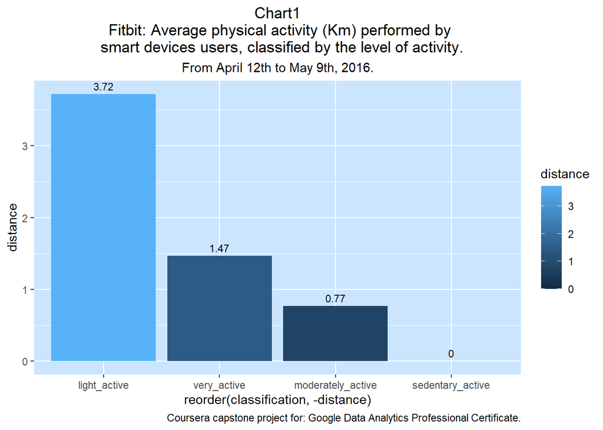

#### *Table3. Fitbit: Average consume of calories by the users while using the APP.*

###### From April 12th to May 9th 2016.

```
## [1] 2358.33
```

#### *Table4. Fitbit: Physical activity in minutes performed by users,*

#### *classified by the level of activity.*

###### From April 12th to May 9th, 2016.

```
##   classification minutes
## 1    very_active   25.19
## 2  fairly_active   18.25
## 3 lightly_active  210.31
## 4      sedentary  768.27
```

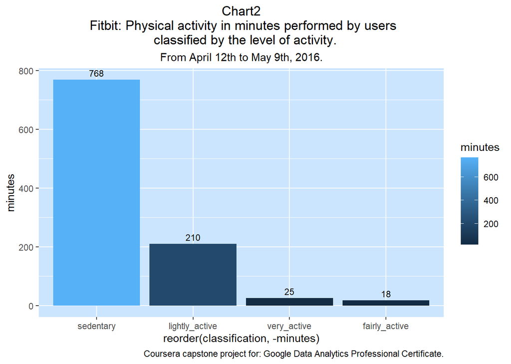

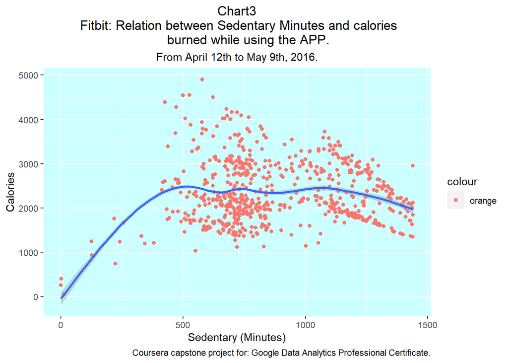

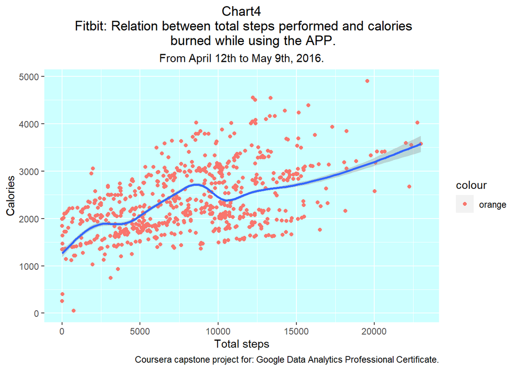

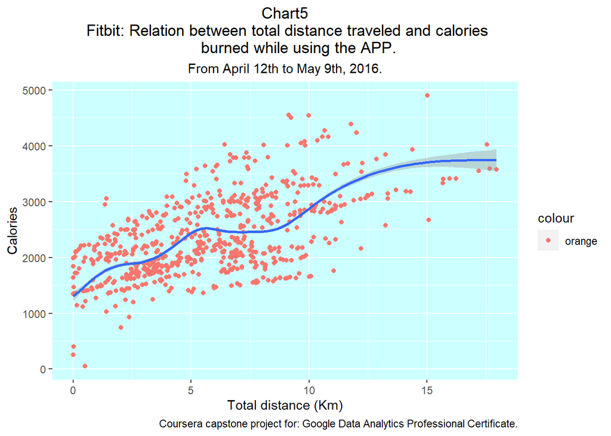

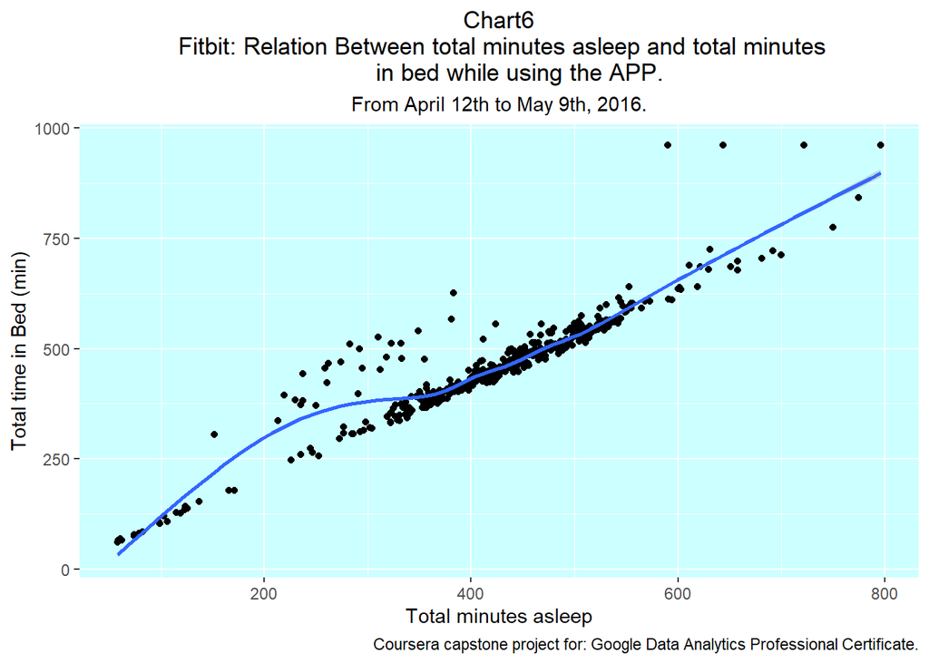

### **Findings from the analysis.**

Base on the information provided and after credibility was determined by using the ROCCC, the following are some insights from the data.

**3. Chart3.**

- It shows relation between the sedentary activity of users and the calories consumed.
- While user is in sedentary ¨mode¨, there is an increase of calories burned until the user reaches 500 minutes.
- From 500 minutes to around 1100 minutes, there is no kind of pattern, Calories consumed are very scattered, there is no relation between minutes and calories consumed.
- From around 1100 minutes to 1500, there is a negative relation between minutes consumed by users and calories burned.

**4. Chart4.**

- It indicates relation between total steps performed by users and calories burned while using the APP.
- Even though the data is very sparse, there is a positive correlation tendency.
- Calories tend to increase while more steps are performed by the users.

**5. Chart5.**

- It indicates relation between total distanced traveled in Km by the users and calories burned while using the APP.
- There is a positive correlation tendency.
- Calories tend to increase while more distance is traveled.

**6. Chart6.**

- It indicates the relation between total minutes asleep and total minutes in bed while using the APP.
- There is a positive correlation tendency.
- The most the users are asleep, there is a direct relation the more time the users are in bed.

# **Phases 6: Act.**

### **Recommendations.**

- Bellabeat marketing should create a strategy to sell the idea that the main goal of buying its smart devices is to increase physical activities and to improve health conditions and not only buying a device.
- That strategy should award users with credits, discounts, cash-back, etc. to women that really uses the smart devices to increase physical activity.
- Collecting and analysis data every period of time to see if the strategy has worked out and if it has helped the company to growth.
- Also, to keep performing analysis on smart devices competitors to see how they are performing.